# NYPD Shooting Report

2024-05-22

The purpose of this report is to analyze, summarize and visualize the NYPD Shooting Incident dataset which reports and categorizes all shooting incidents that occurred in NYC from between 2006 - 2023. To begin we will load all packages required for data management and visualization.

```r
library(ggplot2)
library(data.table)
library(scales)
library(dplyr)
library(lubridate)
library(gganimate)
```

Next we will read the data and store it into variable “dat”. The dataset is in csv format.

```r
setwd("C://MSDS Program//Data Science as a Field//")
dat = read.csv("NYPD_Shooting_Incident_Data__Historic__20240523.csv")
```

First let’s look at how the frequency of shootings has changed over the years. We will first extract a list of all unique years in the dataset. we will then create a dataframe consisting of two columns; year and a count of the number of shooting incidents reported that year. We will then fill up this second column by sorting the dataset by year, iterating through the sorted dataset and updating the count when we detect the year has changed. Finally we will plot the number of occurrences by year as both a bar chart and a scatterplot.

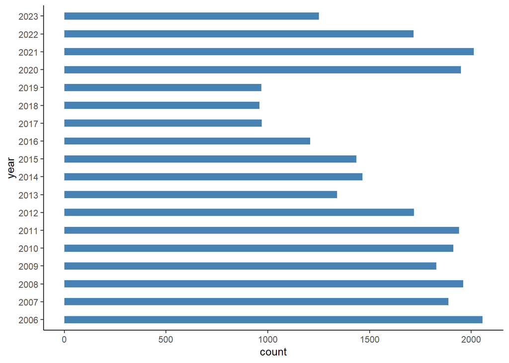

```r
date_split <- function(date){
  y = strsplit(date, "/")[[1]][3]
  return(y)
}

temp_dates = dat$OCCUR_DATE
dat$year  = sapply(temp_dates, date_split)
#head(dat$year)

year_names = sort(unique(dat$year))
year_incident_sorted = data.frame("year" = sort(dat$year))
year_incident_sorted$index = 1:nrow(year_incident_sorted)
year_count = data.frame("year" = year_names, "count" = matrix(0, nrow = length(unique(dat$year)), ncol = 1), row.names = year_names)

count = 1
k = 1
for(i in 2:nrow(year_incident_sorted)){
  if(year_incident_sorted$year[i] != year_incident_sorted$year[i-1]){
    year_count$count[k] = count
    count = 1
    k = k + 1
  }
  count = count + 1
}
year_count$count[nrow(year_count)] = count
p1 = ggplot(data = year_count, aes(x = year, y = count)) + geom_bar(stat="identity", width = 0.4, fill = "steelblue") + theme_classic()
p1 + coord_flip()
```

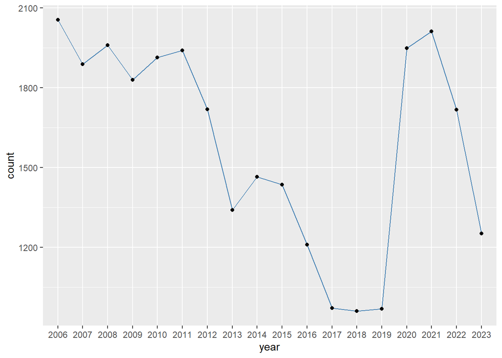

```r
p1a = ggplot(data = year_count, aes(x = year, y = count, group = 1)) + geom_line(color = "steelblue") + geom_point(color = "black")
p1a
```

Looking at the visualizations (particularly the scatterplot), we can see that shooting occurrences has generally trended down from 2006 to 2019 before sharply spiking up between 2019 and 2021. Given the timeframe, I would wager this is most likely due to the pandemic. Shooting occurrences have since regressed back to the mean although not quite at the level from 2017-2019.

Next, let’s analyze the distribution of shooting incidents by borough.

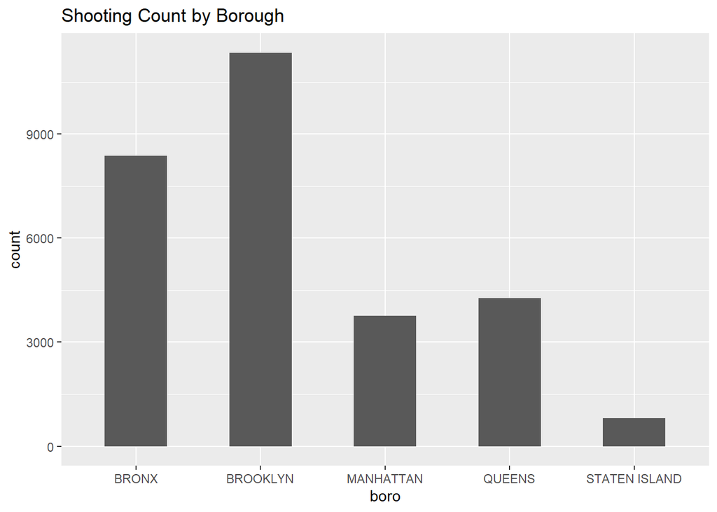

```r
boro_names = unique(dat$BORO)
boro_count = data.frame("boro" = boro_names, "count" = 0)

for(i in 1:nrow(boro_count)){
  name = boro_count$boro[i]
  boro_count$count[i] = length(which(dat$BORO == name))
}
p2 = ggplot(data = boro_count, aes(x = boro, y = count)) +
  geom_bar(stat = "identity", width = 0.5) +
  labs(title = "Shooting Count by Borough")
p2
```

It seems that Brooklyn and the Bronx report a substantially greater number of shootings then the other boroughs. Manhattan and Queens both have a similar profile to one another and Staten Island is substantially lower then any other borough. On the other hand, Staten Island also has a substantially lower population then the other boroughs so perhaps a more accurate metric would be to measure shooting count per capita. Approximating from the 2022 Census:

Bronx: 1,472,653 Brooklyn: 2,736,119 Manhattan: 1,694,250 Queens: 2,405,425 Staten Island: 495,752

Dividing the individual borough shooting counts with their respective populations will then provide us with our shooting count per capita metric.

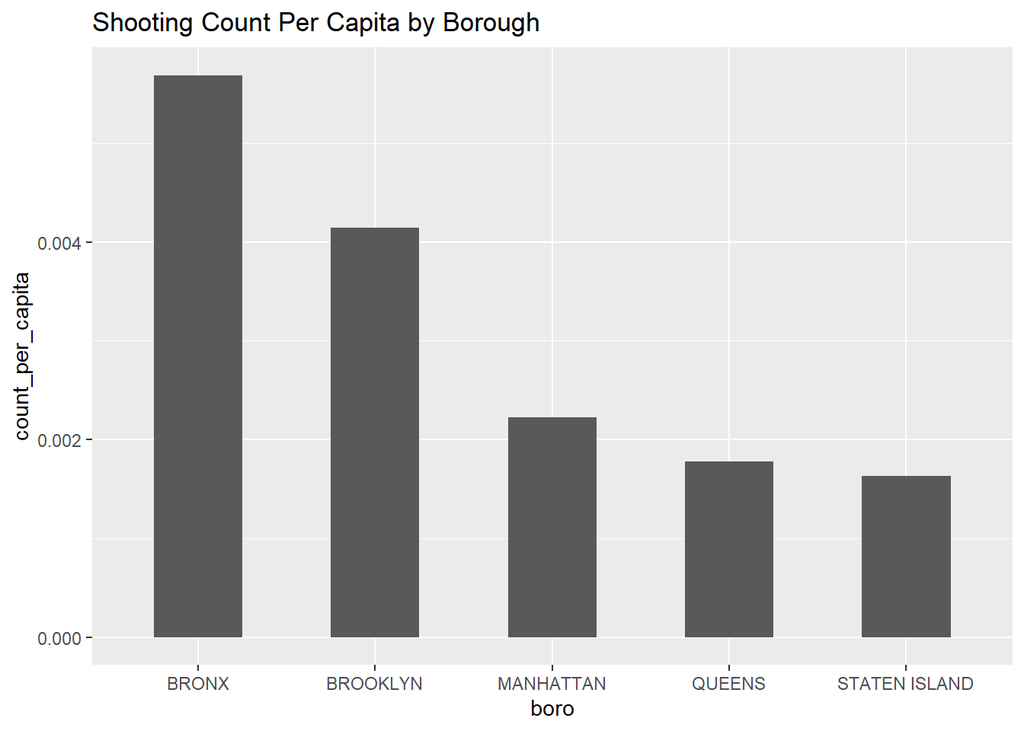

```r
pop = c(1694250, 1472653, 2405425, 2736119, 495752)
boro_count$population = pop
boro_count$count_per_capita = boro_count$count/boro_count$population
p2a = ggplot(data = boro_count, aes(x = boro, y = count_per_capita)) +
  geom_bar(stat = "identity", width = 0.5) +
  labs(title = "Shooting Count Per Capita by Borough")
p2a
```

This paints a slightly different picture. Adjusted for population, Staten Island now reports a similar profile to Manhattan and Queens while the Bronx overtakes Brooklyn in terms of shooting frequency. Both Brooklyn and the Bronx still report substantially higher rates of shooting incidents then other boroughs.

NOTE: In order for the animation to display properly, please ensure you have the [PNG](https://cran.r-project.org/web/packages/png/index.html) and [gifski](https://cran.r-project.org/web/packages/gifski/index.html) packages installed. These can be directly downloaded from CRAN using install.packages().

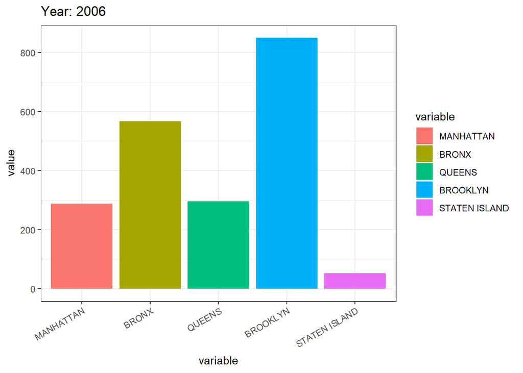

```r
#animated borough count by year to visualize relative changes in shootings by borough over the years
boro_count_year = data.frame("year" = year_count$year, matrix(nrow = nrow(year_count), ncol = nrow(boro_count)))
colnames(boro_count_year) = c("year", boro_count$boro)

for(year in 1:nrow(year_count)){
  for(boro in 1:nrow(boro_count)){
    boro_count_year[year, boro + 1] = length(which(dat$year == year_names[year] & dat$BORO == boro_names[boro]))
  }
}
boro_count_year_long = reshape2::melt(boro_count_year, id = "year", measure = boro_names)

p3_anim = ggplot(boro_count_year_long, aes(x = variable, y = value, fill = variable)) +
  geom_bar(stat='identity') +
  labs(title = 'Year: {closest_state}') +
  theme_bw() +
  transition_states(
    year,
    transition_length = 100,
    state_length = 0.1
  ) +
  ease_aes('sine-in-out') +
  scale_x_discrete(guide = guide_axis(angle = 30))

animate(p3_anim, nframes = 100, end_pause = 10)
```

Now let’s look at the distribution of times at which shootings typically occur.

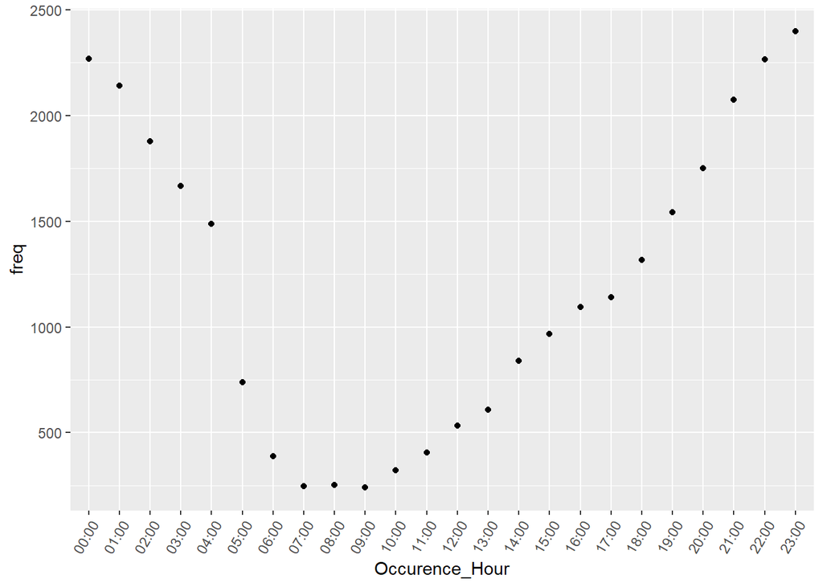

```r
occur_times = data.frame(Occurence_Hour = format(strptime(dat$OCCUR_TIME, "%H:%M:%S"), "%H:00"))
occur_times_count = plyr::count(occur_times)
rm(occur_times)
ggplot(occur_times_count, aes(x = Occurence_Hour, y = freq)) +  geom_point() + scale_x_discrete(guide = guide_axis(angle = 60))
```

It seems the frequency of shooting incidences rises either linearly or semi-exponentially as the hour approaches midnight before dropping off sharply after 4am. The time interval with the lowest number of shootings is between 7am and 9am which is typically the morning rush hour. One possible explanation for this could be that crime-related shootings typically do not occur during the morning because there are too many witnesses. Or that the incidence of shooting among people active during that time period (i.e. morning commuters/full time workers) is lower on average.

Now lets look at the distribution of locations where shootings occur. To do this we will be bucketing the dataset based on location and counting the total number of incidents in each type of location.

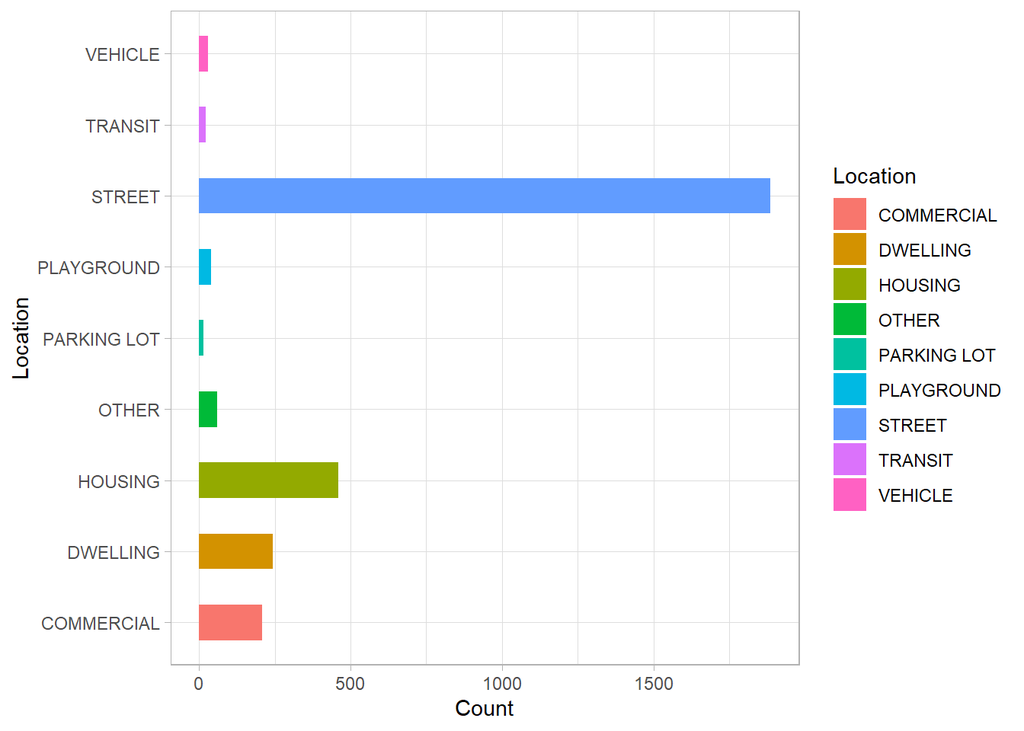

```r
#unique(dat$LOC_OF_OCCUR_DESC)
#unique(dat$LOC_CLASSFCTN_DESC)
inside_outside_count = plyr::count(dat$LOC_OF_OCCUR_DESC)
location_class_count = plyr::count(dat$LOC_CLASSFCTN_DESC)
location_class_count = location_class_count[c(3:nrow(location_class_count)),]
colnames(location_class_count) = c("Location", "Count")

ggplot(location_class_count, aes(x= Location, y = Count, fill = Location)) +
  geom_bar(stat="identity", width = 0.5) +
  coord_flip() +
  theme_light()
```

The vast majority of shootings occur either in the streets or at a residence (Housing + Dwelling) with a nontrivial proportion also occuring on commercial propeties. Perhaps this reflects how often these locations occur in the environment (i.e. when outside, one is almost always on a street in the city). It could also reflect the underlying distribution of why the shooting occured based on frequency of cause. For example if the majority of shootings were done with criminal intentions and criminal intentions are most likely to occur in the streets, then it would not be surprising that the majority of shooting incidents occur in the streets. It could also be that due to the probability of witnesses, shootings on the street are the type most likely to be reported.

Now lets look at the fatality aspect of shootings and test whether there is correlation between location and whether a shooting is fatal or not:

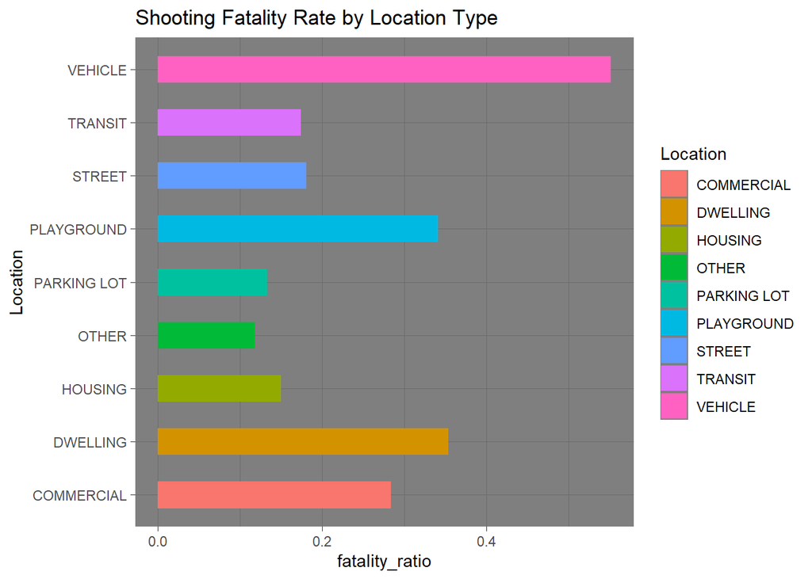

```r
dat_fatal = filter(dat, dat$STATISTICAL_MURDER_FLAG == "true")
dat_nonfatal = filter(dat, dat$STATISTICAL_MURDER_FLAG == "false")

location_class_count_fatal = plyr::count(dat_fatal$LOC_CLASSFCTN_DESC)
location_class_count_fatal = location_class_count_fatal[c(2:nrow(location_class_count_fatal)),]
colnames(location_class_count_fatal) = c("Location", "Count")

fatality_ratio = location_class_count_fatal$Count / location_class_count$Count
location_class_count = data.frame(location_class_count, fatal_count = location_class_count_fatal$Count, fatality_ratio)

ggplot(location_class_count, aes(x = Location, y = fatality_ratio, fill = Location)) +
  geom_bar(stat = "identity", width = 0.5) +
  labs(title = "Shooting Fatality Rate by Location Type") +
  coord_flip() +
  theme_dark()
```

Digging deeper into this, lets finally look at the shootings as a function of age. What is the distribution of the shooter’s age? Does this distribution change as we focus only on fatal shootings? In other words does the age of the shooter make it more or less likely for the shooting to be fatal?

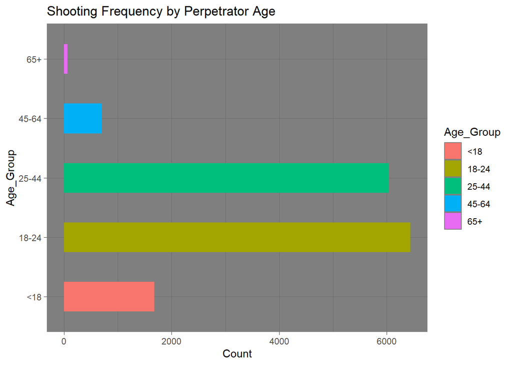

```r
perp_age_count = data.frame(plyr::count(dat$PERP_AGE_GROUP))
perp_age_count = perp_age_count[c(3,6, 8:10),]
perp_age_count_fatal = data.frame(plyr::count(dat_fatal$PERP_AGE_GROUP))
perp_age_count_fatal = perp_age_count_fatal[3:7,]
colnames(perp_age_count) = colnames(perp_age_count_fatal) = c("Age_Group", "Count")
perp_age_count_fatality_ratio = perp_age_count_fatal$Count/perp_age_count$Count
perp_age_count = data.frame(perp_age_count, Fatal_Count = perp_age_count_fatal$Count, Ratio = perp_age_count_fatality_ratio)


ggplot(perp_age_count, aes(x = Age_Group, y = Count, fill = Age_Group)) +
  geom_bar(stat = "identity", width = 0.5) +
  labs(title = "Shooting Frequency by Perpetrator Age") +
  coord_flip() +
  theme_dark()
```

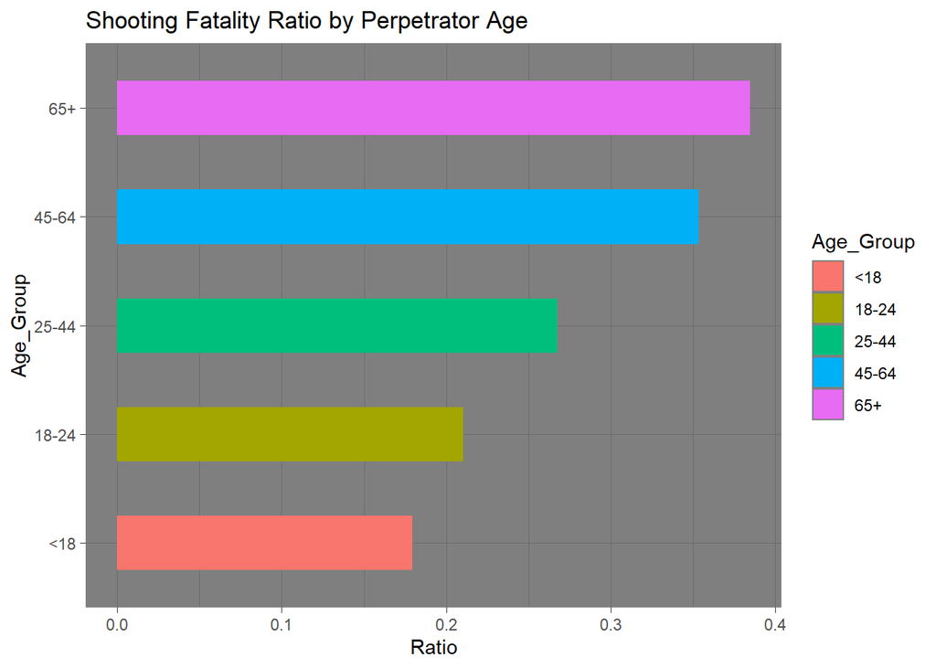

```r
ggplot(perp_age_count, aes(x = Age_Group, y = Ratio, fill = Age_Group)) +
  geom_bar(stat = "identity", width = 0.5) +
  labs(title = "Shooting Fatality Ratio by Perpetrator Age") +
  coord_flip() +
  theme_dark()
```

These two visualizations together paint an interesting picture. While the perpetrators in the vast majority of shooting incidents are between the ages of 18 and 44 (i.e. the younger population), the chance the shooting being fatal rises dramatically when the perpetrator is 45 or older. Perhaps this reflects the differing intentions (on average) behind the shooting with the younger perpetrator more likely to commit to shooting due to criminal activity while the older perpetrator is more likely to commit the shooting due to intentions that are more likely to lead to murder. Without a far more detailed study that controls for various confounding variables however, this is merely hypothesis.